# COVID-19 Final Project

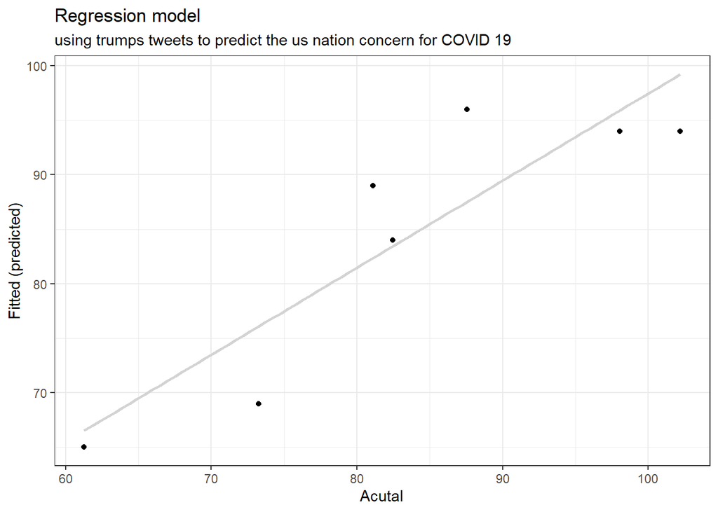

```r
### plot that shows the the efficient of the model on the test data
my_test_predict %>%
  ggplot() +
  geom_point(aes(predicted, Diff))+
  geom_smooth(aes(predicted, Diff), method="lm", se=FALSE, color="lightgrey") +
  labs(x="Acutal", y="Fitted (predicted)", title="Regression model", subtitle="using trumps tweets to predict the us nation concern for COVID 19") +
  theme_bw()
```

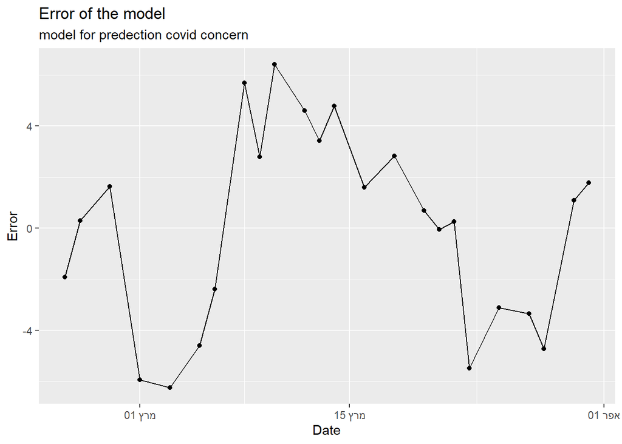

```r
### plot that shows the error of the model in the train prediction

my_train_predict %>%
  mutate(error=Diff-predicted) %>%
  ggplot(aes(x=Date, y=error)) +
  geom_line() +
  geom_point() +
  labs(x="Date", y="Error", title="Error of the model", subtitle = "model for predection covid concern")
```

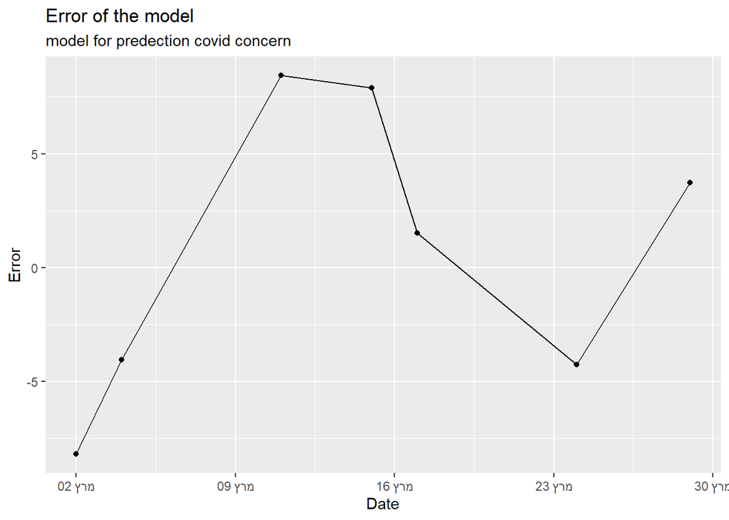

```r
### plot that shows the error of the model in the test prediction

my_test_predict %>%
  mutate(error=Diff-predicted) %>%
  ggplot(aes(x=Date, y=error)) +
  geom_line() +
  geom_point() +
  labs(x="Date", y="Error", title="Error of the model", subtitle = "model for predection covid concern")
```

## Part 3: Political Orientation, Covid Mobility Restrictions and Covid Cases in the US

As we have seen in the Concern dataset exploration above, the democratic party voters are more concerned about a Covid outbreak than the republican voters, so political orientation in the US plays a role in how people react to the Corona pandemic.

Based on that, we would like to know how the political orientation in the US plays a role when it comes to adhering the Covid 19 mobility restrictions, and how that affects the number of cases in each state, for us to find out we need the right data, we did an extensive research collecting the required data, it was time consuming but worth it, we collected several datasets.

One dataset is for the 2016 US election results in every state -`red_blue.csv`. Elections in the US occur every 4 years and the Corona pandemic started to take place in the US during January 2020, we needed data about each state and the winning party in it democratic or republican, we found such tabular data [here](https://indzara.com/2016/11/2016-u-s-presidential-election-tracker-excel-template/), but after validating the data we noticed that it was not updated, these were not the final results of the elections, but because we were comfortable with the ready tabular form and did not find anything like it (others required scraping and tidying), we decided to update the data from [this](https://www.politico.com/2016-election/results/map/president/) validated source, this way it would be less time consuming than scraping and tidying the data from the other sources.

It is worth mentioning (for those who have a weak background in the topic), that during the 2016 elections the democratic party candidate was Hilary Clinton, and the republican party candidate was Donald Trump, in the elections dataset under the column `WINNER` is stated the winning party’s candidate name. Simply put, `Trump` means the republican party won the state, and `Clinton` means that the democrats did.

Now after gathering data about the political orientation, let’s look at the following visualization to get an idea about the cases in the blue states (democratic/Clinton) and the red states (republican/Trump).

```r
#Importing the election results dataset
Election1<-read.csv("data/red_blue.csv")
Election1<-Election1%>%rename(State=ABBR)

#Take a look at the data after importing it
glimpse(Election1)
```

```
## Rows: 51
## Columns: 4
## $ ן..STATE        <chr> "Alabama", "Alaska", "Arizona", "Arkansas", "Californi~
## $ State           <chr> "AL", "AK", "AZ", "AR", "CA", "CO", "CT", "DE", "DC", ~
## $ ELECTORAL.VOTES <int> 9, 3, 11, 6, 55, 9, 7, 3, 3, 29, 16, 4, 4, 20, 11, 6, ~
## $ WINNER          <chr> "Trump", "Trump", "Trump", "Trump", "Clinton", "Clinto~
```

```r
#col name correction
Election1<-Election1%>%rename(STATE=ן..STATE)

#saveRDS(Election1, file = "clean_data/Election1.rds")

#Joining the elections dataset with the cases dataset by state
#And some processing depending on what we saw from the glimpse, changing column names etc..
elec_cases<-cases1%>%inner_join(Election1,by="State")
elec_cases<-elec_cases%>%rename(ABBR=State)

#Take a look at the result
glimpse(elec_cases)
```

```
## Rows: 24,480
## Columns: 7
## $ Date            <date> 2020-01-21, 2020-01-21, 2020-01-21, 2020-01-21, 2020-~
## $ ABBR            <chr> "AK", "AZ", "CA", "CO", "HI", "ID", "MT", "NM", "NV", ~
## $ Region          <chr> "West", "West", "West", "West", "West", "West", "West"~
## $ Cases           <dbl> 0, 0, 0, 0, 0, 0, 0, 0, 0, 0, 0, 1, 0, 0, 0, 0, 0, 0, ~
## $ STATE           <chr> "Alaska", "Arizona", "California", "Colorado", "Hawaii~
## $ ELECTORAL.VOTES <int> 3, 11, 55, 9, 4, 4, 3, 5, 6, 7, 6, 12, 3, 6, 20, 11, 6~
## $ WINNER          <chr> "Trump", "Trump", "Clinton", "Clinton", "Clinton", "Tr~
```

```r
#Grouping by winner (party) and date
#Keeping only 2020 data
elec_cases1<-elec_cases%>%

  group_by(Date,WINNER)%>%

  summarise(cases=sum(Cases))%>%

  filter(between(Date,ymd("2020-01-21"),ymd("2020-12-31")))
#Take a look at the result
head(elec_cases1)
```

```
## # A tibble: 6 x 3
## # Groups:   Date [3]
##   Date       WINNER  cases
##   <date>     <chr>   <dbl>
## 1 2020-01-21 Clinton     1
## 2 2020-01-21 Trump       0
## 3 2020-01-24 Clinton     1
## 4 2020-01-24 Trump       0
## 5 2020-01-25 Clinton     1
## 6 2020-01-25 Trump       0
```

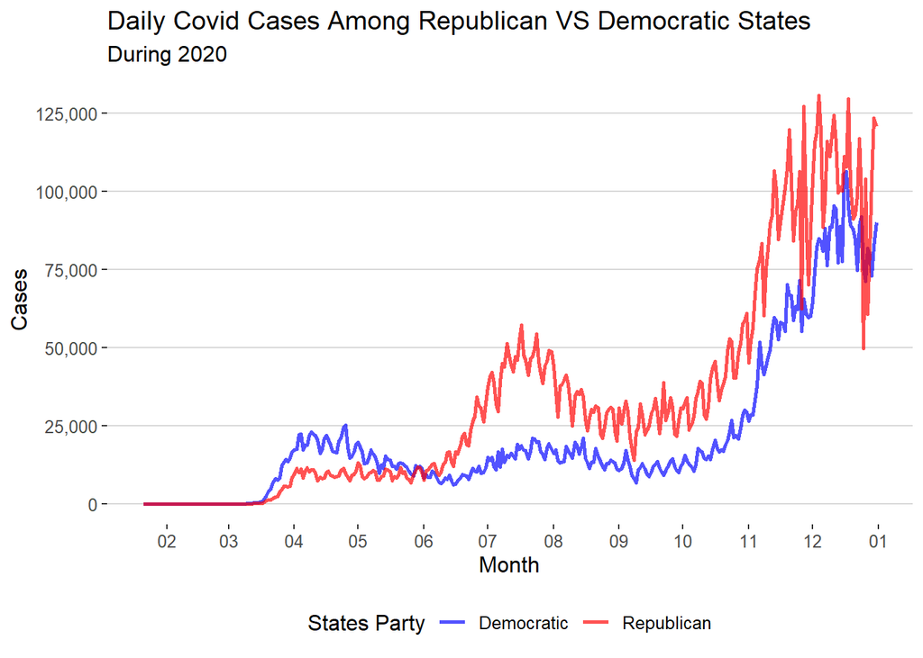

```r
#Plotting
parties_plt<-ggplot(elec_cases1,aes(Date ,cases,color=WINNER))+

  geom_line(size=1, alpha=0.68)+

  scale_x_date(date_breaks = "1 month", date_labels = "%m")+

  scale_y_continuous(labels= scales::comma,breaks = seq(from = 0, to = 200000, by = 25000))+

  scale_color_manual(labels=c("Democratic", "Republican"), values =c("Blue", "red"))+

  labs(title="Daily Covid Cases Among Republican VS Democratic States", subtitle = "During 2020", x="Month", y="Cases", color="States Party")+

  theme_hc()

parties_plt
```

It is expected to have a rise in both lines, what’s interesting is starting from June until the end of the year, the republican states have higher numbers of cases than the democratic states. Let’s further explore the data.

We gathered [data](https://www.washingtonpost.com/nation/interactive/2021/coronavirus-timeline/) about mobility restrictions and events in the US during 2020, restrictions such as lockdowns, stay-at-home orders etc… Each restriction or event related to mobility has a date, we’ll add those the plot and we’ll distinguish between strict restrictions vs facilitated, and see how the cases were affected by that, the distinction will be done by text analysis.

```r
#From the data source we picked events related to mobility only
#(for example events related to masks were not included)
event_date<-c("2020-03-16", "2020-03-23", "2020-04-02", "2020-04-11", "2020-04-17", "2020-04-24", "2020-04-30", "2020-05-01", "2020-05-19", "2020-05-25", "2020-05-31", "2020-06-26", "2020-07-08", "2020-08-01", "2020-08-07", "2020-10-02", "2020-11-03")

event_date<-event_date%>%ymd()

event<-c("Trump tells Americans to avoid gathering in groups of more than 10 and to stop eating in restaurants and taking nonessential trips for the next 15 days. It is the closest the federal government will come to calling for a nationwide shutdown.","Under pressure from conservatives, Trump says he’s considering nixing the guidelines for social distancing he announced a week earlier, saying: “We cannot let the cure be worse than the problem itself.",
         "Most Americans are living under stay-at-home orders.",
         "The U.S. coronavirus death toll is the highest in the world, passing Italy.",
         "Trump tweets “LIBERATE MINNESOTA,” “LIBERATE MICHIGAN” and “LIBERATE VIRGINIA,” encouraging protesters who are ignoring social distancing guidance and demanding that their states reopen. Shutdown opposition is spreading, aided by Trump and right-wing groups.",
         "Georgia Gov. Brian Kemp, a Republican and one of the last leaders to issue a stay-at-home order, allows business to reopen. Georgia is the first state to do so.",
         " The federal government’s social distancing guidelines expire, and most states push ahead with reopening plans.",
         "From Michigan to California, gun rights supporters, anti-vaccination activists and business owners protest coronavirus restrictions. Some are heavily armed, some are displaying hate symbols.",
         " Forty-three states have begun at least some form of reopening, hoping to boost their economies. Seven never had stay-at-home orders.",
         "Crowded beaches, parties and pools during Memorial Day weekend alarm health officials. One calls the scene an “international example of bad judgment.",
         "Millions flood streets across the country to protest the killing of George Floyd and police violence against Black Americans, sparking fears of a new round of virus outbreaks. Health officials will later say that the protests, which continue for days, probably did not cause a spike in cases.",
         "The governors of Texas and Florida reverse course and shut down bars in their states as infections and hospitalizations soar.",
         "Trump pressures the CDC to change guidance on school reopening and threatens to cut funding for schools that do not fully open for in-person learning.",
         "A superintendent of schools in rural Arizona issues one of many warnings from educators thinking about reopening schools: “I’m sorry, but it’s a fantasy. Kids will get sick, or worse. Family members will die. Teachers will die.",
         " Nearly 500,000 people converge on Sturgis, S.D., for a 10-day motorcycle rally. Attendees gather in bars, restaurants and tattoo parlors. The virus spreads, and there are additional outbreaks in the Midwest.",
         "Trump says he and first lady Melania Trump have tested positive for the virus. Less than 24 hours later, he is flown to a hospital for treatment.",
         "It is Election Day, and many Americans already have cast their ballots in a record-setting, pandemic-spurred wave of early voting.")

#The restrictions/events df
restriction<-data.frame(event_date, event)

#saveRDS(restriction, file = "clean_data/restriction.rds")
#check it out

head(restriction)
```

```
##   event_date
## 1 2020-03-16
## 2 2020-03-23
## 3 2020-04-02
## 4 2020-04-11
## 5 2020-04-17
## 6 2020-04-24
##                                                                                                                                                                                                                                                                event
## 1                  Trump tells Americans to avoid gathering in groups of more than 10 and to stop eating in restaurants and taking nonessential trips for the next 15 days. It is the closest the federal government will come to calling for a nationwide shutdown.
## 2                                                          Under pressure from conservatives, Trump says he’s considering nixing the guidelines for social distancing he announced a week earlier, saying: “We cannot let the cure be worse than the problem itself.
## 3                                                                                                                                                                                                               Most Americans are living under stay-at-home orders.
## 4                                                                                                                                                                                        The U.S. coronavirus death toll is the highest in the world, passing Italy.
## 5 Trump tweets “LIBERATE MINNESOTA,” “LIBERATE MICHIGAN” and “LIBERATE VIRGINIA,” encouraging protesters who are ignoring social distancing guidance and demanding that their states reopen. Shutdown opposition is spreading, aided by Trump and right-wing groups.
## 6                                                                                                   Georgia Gov. Brian Kemp, a Republican and one of the last leaders to issue a stay-at-home order, allows business to reopen. Georgia is the first state to do so.
```

Let’s perform text analysis to the events, to see which events are facilitating mobility restriction and which are restricting.

```r
#First, Tokenizing
tokenized_rest<-restriction %>%

  unnest_tokens(word, event, token = "ngrams", n = 2, n_min = 1) %>%

  anti_join(stop_words, by = "word")

#Word Frequency
restr_ngrams <- tokenized_rest %>%

  group_by(event_date,word) %>%

  summarise(n = n(), .groups = "drop") %>%
  #Arrange the words frequency in descending order
  arrange(desc(n))


head(restr_ngrams)
```

```
## # A tibble: 6 x 3
##   event_date word         n
##   <date>     <chr>    <int>
## 1 2020-04-17 liberate     3
## 2 2020-04-17 trump        2
## 3 2020-04-24 georgia      2
## 4 2020-05-01 some are     2
## 5 2020-08-01 die          2
## 6 2020-08-01 schools      2
```

```r
#Sentiment Analysis
 Sentiment_count<-restr_ngrams%>%

  inner_join(get_sentiments("bing"), by = "word") %>%

  group_by(event_date, sentiment) %>%

   summarise(n=n())
 #In this df the negative words received a negative count value
 #this is because, we'll combine the negative and positive count
 #for each date, and based on the result we'll determine if the event was
 #restrictive or facilitating
 sentiment_count <- Sentiment_count %>%

mutate(n = if_else(sentiment == 'negative', -n, n))

head(sentiment_count)
```

```
## # A tibble: 6 x 3
## # Groups:   event_date [4]
##   event_date sentiment     n
##   <date>     <chr>     <int>
## 1 2020-03-16 positive      1
## 2 2020-03-23 negative     -1
## 3 2020-03-23 positive      2
## 4 2020-04-11 negative     -2
## 5 2020-04-17 negative     -1
## 6 2020-04-17 positive      4
```

```r
#f refers to facialiting
restriction_sent<-sentiment_count %>%

  group_by(event_date) %>%

  summarise(total_count=sum(n))%>%

  mutate(event_type = if_else(total_count >=0, "f", "r"))

restriction_sent
```

```
## # A tibble: 15 x 3
##    event_date total_count event_type
##    <date>           <int> <chr>
##  1 2020-03-16           1 f
##  2 2020-03-23           1 f
##  3 2020-04-11          -2 r
##  4 2020-04-17           3 f
##  5 2020-04-24          -1 r
##  6 2020-04-30          -1 r
##  7 2020-05-01          -2 r
##  8 2020-05-19           1 f
##  9 2020-05-25          -3 r
## 10 2020-05-31          -5 r
## 11 2020-06-26          -1 r
## 12 2020-07-08           2 f
## 13 2020-08-01          -4 r
## 14 2020-08-07          -1 r
## 15 2020-10-02           1 f
```

```r
rest_sent_event<-inner_join(restriction_sent, restriction)
glimpse(rest_sent_event)
```

```
## Rows: 15
## Columns: 4
## $ event_date  <date> 2020-03-16, 2020-03-23, 2020-04-11, 2020-04-17, 2020-04-2~
## $ total_count <int> 1, 1, -2, 3, -1, -1, -2, 1, -3, -5, -1, 2, -4, -1, 1
## $ event_type  <chr> "f", "f", "r", "f", "r", "r", "r", "f", "r", "r", "r", "f"~
## $ event       <chr> "Trump tells Americans to avoid gathering in groups of mor~
```

After validating the data, it appears that this text analysis model did not determine very well the event type ,this is due to many factors, one is the not very convenient word lexicon for the Covid context, so we’ll simply update the final df with the validated event_type:

```r
rest_sent_event<-rest_sent_event%>%mutate(event_type=c("r", "f", "r", "f", "f", "f", "f", "f", "f", "f", "r", "f","r", "f", "r"))
```

Let’s add those events to the previous plot, and specify by color the event type, mobility facilitating or restricting:

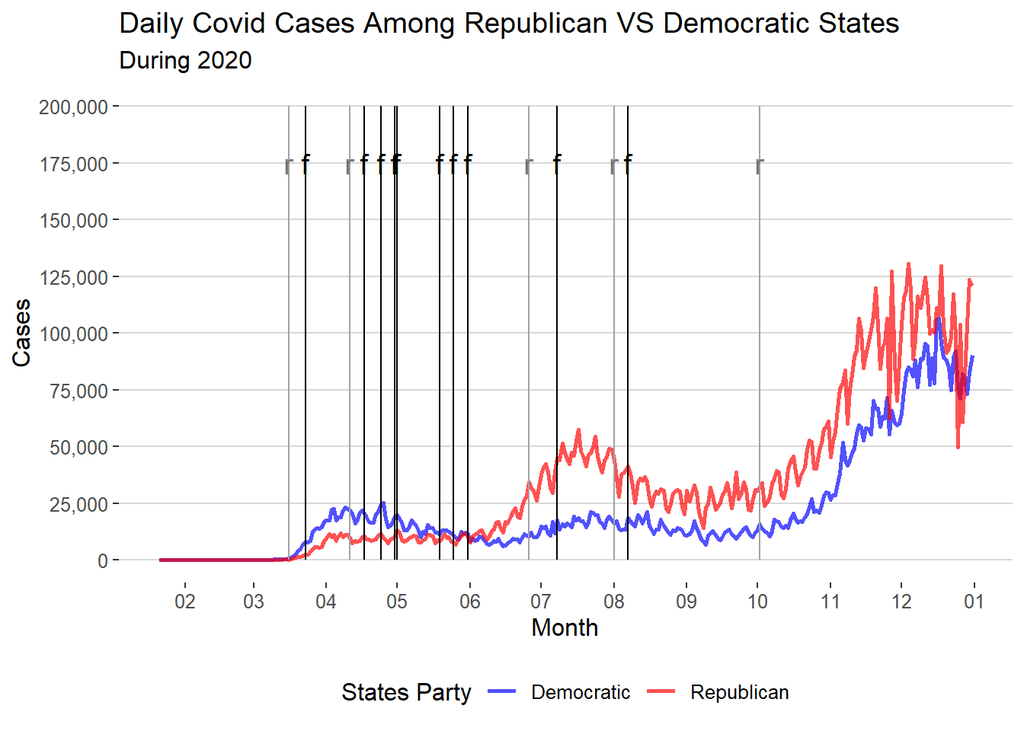

```r
#glimpse(elec_cases1)
#Becase color in segment by event_state made several problems
#this is an alternative solution to color=event_type
fac<-rest_sent_event%>%filter(event_type=="f")
rest<-rest_sent_event%>%filter(event_type=="r")

parties_plt+
  geom_segment(data = fac, aes(x = event_date, y = 200000, xend = event_date, yend =0), colour="black") +

  geom_segment(data = rest, aes(x = event_date, y = 200000, xend = event_date, yend =0), colour="grey64") +

  geom_text(data = fac , aes(x = event_date, y = 175000, label = event_type), color = "black", size=5)+

 geom_text(data = rest , aes(x = event_date, y = 175000, label = event_type), color = "grey46", size=5)
```

Now that we know the type of events, we can guess new conclusions about the data, as we can see around June there were many facilitated mobility events, and from there on we note a rise in the number of cases in the republican states, while in the democratic states it barely rises, it is almost steady, then comes a restricting mobility event around July also from there on the rise continues in the republican states while remains almost steady in the democratic ones, could it be that citizens in the republican state are less adhere to the restrictions? and are the democrats more adhere? To find out more about that we needed a new dataset-`state_visits_Travel & Transport.csv`, which is taken from [here](https://data.world/covid-19-data/foursquare-mobility-data-during-covid-19), it provides mobility and travels data for every state in the given time period (2020).

Let’s import it and check it out:

```r
mobility<-read.csv("data/state_visits_Travel & Transport.csv")

head(mobility)
```

```
##   X X2020.02.01 X2020.02.02 X2020.02.03 X2020.02.04 X2020.02.05 X2020.02.06
## 1 0      183678      173713      199535      188142      176621      170221
## 2 1       27703       25374       27651       29918       28169       29154
## 3 2      360895      310872      336844      334667      336239      335419
## 4 3       81786       73217       82289       76463       79064       80172
## 5 4     1564575     1294474     1391933     1414442     1449392     1547801
## 6 5      150481      134724      149484      128490      152724      160068
##   X2020.02.07 X2020.02.08 X2020.02.09 X2020.02.10 X2020.02.11 X2020.02.12
## 1      200309      191276      186128      176776      179281      193864
## 2       30119       25671       24383       30010       31182       29728
## 3      362813      349159      317375      363169      328709      349387
## 4       90999       78861       73746       82908       81041       78013
## 5     1615121     1548291     1327744     1485760     1510895     1534314
## 6      149492      150021      133344      143684      152763      152247
##   X2020.02.13 X2020.02.14 X2020.02.15 X2020.02.16 X2020.02.17 X2020.02.18
```

[output cut: 188 more lines]

As we can see the data needs cleaning, manipulating and pivoting. Let’s do so:

```r
#Pivot longer
pivoted_mobility<-mobility %>%

  pivot_longer(!NAME, names_to = "date", values_to = "visits")

glimpse(pivoted_mobility)
```

```
## Rows: 8,996
## Columns: 3
## $ NAME   <chr> "Alabama", "Alabama", "Alabama", "Alabama", "Alabama", "Alabama~
## $ date   <chr> "X", "X2020.02.01", "X2020.02.02", "X2020.02.03", "X2020.02.04"~
## $ visits <dbl> 0, 183678, 173713, 199535, 188142, 176621, 170221, 200309, 1912~
```

```r
#Manupilating
pivoted_mobility<-pivoted_mobility%>%rename(STATE=NAME)
glimpse(pivoted_mobility)
```

```
## Rows: 8,996
## Columns: 3
## $ STATE  <chr> "Alabama", "Alabama", "Alabama", "Alabama", "Alabama", "Alabama~
## $ date   <chr> "X", "X2020.02.01", "X2020.02.02", "X2020.02.03", "X2020.02.04"~
## $ visits <dbl> 0, 183678, 173713, 199535, 188142, 176621, 170221, 200309, 1912~
```

```r
#Joining the elections results df with mobility data for the analysis
mobi_elec<-pivoted_mobility%>%inner_join(Election1,by="STATE")
mobi_elec
```

```
## # A tibble: 8,650 x 6
##    STATE   date        visits State ELECTORAL.VOTES WINNER
##    <chr>   <chr>        <dbl> <chr>           <int> <chr>
##  1 Alabama X                0 AL                  9 Trump
##  2 Alabama X2020.02.01 183678 AL                  9 Trump
##  3 Alabama X2020.02.02 173713 AL                  9 Trump
##  4 Alabama X2020.02.03 199535 AL                  9 Trump
##  5 Alabama X2020.02.04 188142 AL                  9 Trump
##  6 Alabama X2020.02.05 176621 AL                  9 Trump
##  7 Alabama X2020.02.06 170221 AL                  9 Trump
##  8 Alabama X2020.02.07 200309 AL                  9 Trump
##  9 Alabama X2020.02.08 191276 AL                  9 Trump
## 10 Alabama X2020.02.09 186128 AL                  9 Trump
## # ... with 8,640 more rows
```

```r
#cleaning
mobi_elec$date <- gsub("X", "", mobi_elec$date)

#tidying
mobi_elec<-mobi_elec%>%mutate(date=date%>%ymd())

#dealing with null values in accordance to the context
mobi_elec<-mobi_elec[!(is.na(mobi_elec$visits) | mobi_elec$visits=="" | mobi_elec$visits==0), ]

head(mobi_elec)
```

```
## # A tibble: 6 x 6
##   STATE   date       visits State ELECTORAL.VOTES WINNER
##   <chr>   <date>      <dbl> <chr>           <int> <chr>
## 1 Alabama 2020-02-01 183678 AL                  9 Trump
## 2 Alabama 2020-02-02 173713 AL                  9 Trump
## 3 Alabama 2020-02-03 199535 AL                  9 Trump
## 4 Alabama 2020-02-04 188142 AL                  9 Trump
## 5 Alabama 2020-02-05 176621 AL                  9 Trump
## 6 Alabama 2020-02-06 170221 AL                  9 Trump
```

```r
#saveRDS(mobi_elec, file = "clean_data/mobi_elec.rds")

#Grouping by date and party
mobi_grouped<-mobi_elec%>%

  group_by(date,WINNER)%>%

  summarise(visits=sum(visits))
head(mobi_grouped)
```

```
## # A tibble: 6 x 3
## # Groups:   date [3]
##   date       WINNER   visits
##   <date>     <chr>     <dbl>
## 1 2020-02-01 Clinton 5067482
## 2 2020-02-01 Trump   5935041
## 3 2020-02-02 Clinton 4438451
## 4 2020-02-02 Trump   5494139
## 5 2020-02-03 Clinton 5680949
## 6 2020-02-03 Trump   6286914
```

Now let’s see in the following plot the visits and mobility/traveling data in the republican and the democratic states, in accordance with the mobility restrictions events.

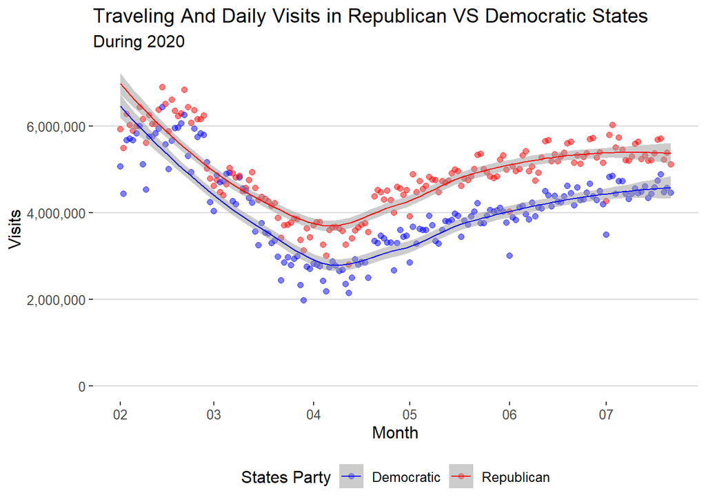

```r
#Plotting
visits_plt<-ggplot(mobi_grouped,aes(date ,visits,color=WINNER))+

  geom_point(size=1.7, alpha=0.5)+

  geom_smooth(size=0.5, alpha=0.5)+

  scale_x_date(date_breaks = "1 month", date_labels = "%m")+

  scale_y_continuous(labels= scales::comma)+

  scale_color_manual(labels=c("Democratic", "Republican"), values =c("Blue", "red"))+

  labs(title="Traveling And Daily Visits in Republican VS Democratic States", subtitle = "During 2020", x="Month", y="Visits", color="States Party")+

  theme_hc()

visits_plt
```

We can see that there is an obvious difference in the number of visits between the republican and the democratic states, at the beginning of the year we can say that they have similar data, but as time goes by we can cleary see that the republican tops the democratic. Let’s add the events to see which party was more responsive to the restrictions

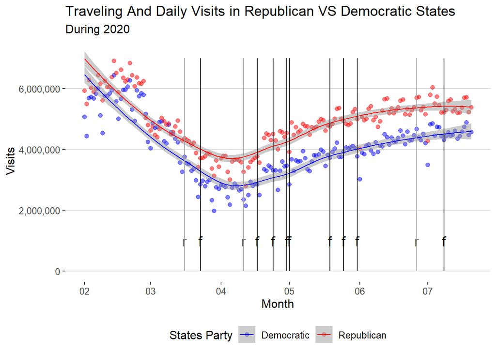

```r
visits_plt+
  geom_segment(data = fac, aes(x = event_date, y = 7000000, xend = event_date, yend =0), colour="black") +

  geom_segment(data = rest, aes(x = event_date, y = 7000000, xend = event_date, yend =0), colour="grey64") +

  geom_text(data = fac , aes(x = event_date, y = 1000000, label = event_type), color = "black", size=5)+

 geom_text(data = rest , aes(x = event_date, y = 1000000, label = event_type), color = "grey46", size=5)+

  #scaling x to fit the range in the 2 plotting datasets
   scale_x_date(date_breaks = "1 month",
                 labels=date_format("%m"),limits = as.Date(c('2020-02-01','2020-07-20')))
```

Now after adding the events, let’s see how the number of visits changes for every party as time goes by and different types of mobility events occur.

But since we lack important data about the population we can’t say much, especially that the lines for both parties behave similarly for the different events. Sadly after unsuccessful findings in extensive research for a good population estimation dataset for the blue and red states in every month in 2020, we’ll have to try another way to shape a better conclusion.

Let’s check another visualization that might help in the conclusion:

```r
#Joining the cases and visits dfs
visits_cases<-inner_join(mobi_grouped, elec_cases1, by=c("date"="Date"))

glimpse(visits_cases)
```

```
## Rows: 608
## Columns: 5
## Groups: date [152]
## $ date     <date> 2020-02-01, 2020-02-01, 2020-02-01, 2020-02-01, 2020-02-02, ~
## $ WINNER.x <chr> "Clinton", "Clinton", "Trump", "Trump", "Clinton", "Clinton",~
## $ visits   <dbl> 5067482, 5067482, 5935041, 5935041, 4438451, 4438451, 5494139~
## $ WINNER.y <chr> "Clinton", "Trump", "Clinton", "Trump", "Clinton", "Trump", "~
## $ cases    <dbl> 1, 0, 1, 0, 3, 0, 3, 0, 0, 1, 0, 1, 0, 0, 0, 0, 2, 0, 2, 0, 0~
```

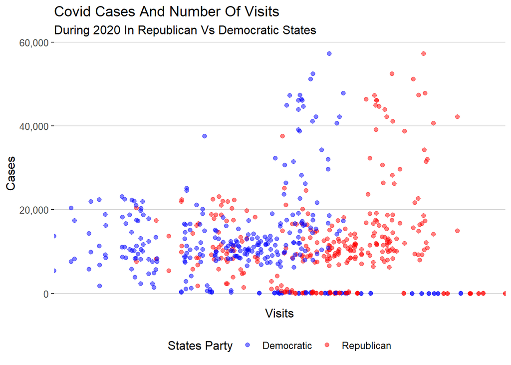

```r
ggplot(visits_cases, aes(x=visits, y=cases, color=WINNER.x))+

  geom_point(size=1.7, alpha=0.5)+

  scale_x_discrete()+

  scale_y_continuous(labels= scales::comma)+

  scale_color_manual(labels=c("Democratic", "Republican"), values =c("Blue", "red"))+

  labs(title="Covid Cases And Number Of Visits", subtitle = "During 2020 In Republican Vs Democratic States", x="Visits", y="Cases", color="States Party")+

  theme_hc()
```

There’s no clear connection between the two variables, also nothing interesting to note between the two parties.